# R Fundamentals Part 4: For loops and functions

D-Lab

September 8, 2018

#Learning objectives **Part 1:**  
1. Variable definition (three piece recipe): *`X <- 5`*  
2. Data types: *numeric, integer, character, logical, factor*  
3. Data structures: *vector, list, matrix, data frame*  
4. Pseudo-random generation: *`set.seed`, `seq`, `:`, `runif`, `rnorm`, `sample`*  
5. Save and practice: *`write.csv()` and `swirl()`*

**Part 2:**  
1. Set your working directory to the R-Fundamentals “data” folder.  
2. Load the `animals` data frame  
3. Load the `sleep_VIM` data set  
4. Subsetting: *one (`$`) versus two dimensions (`[ , ]`)*  
5. Identify and count missing data: *`sum` and `is.na`*  
6. Wide and long format data: *`melt` and `dcast`*

**Part 3:**  
1. Summarizing data: *`summary`, `describe`, `table`*  
2. Plotting data: *`hist`, `plot`, `boxplot`*  
3. ggplot2: *`+`, three parts: data, aes, geom*  
4. Testing: *`t.test`, `aov`, `TukeyHSD`, `cor.test`, `lm`*

**Part 4:**  
1. For loops: *`for`, `if`, `else`, `ifelse`*  
2. Functions: *`function`*  
3. Automation - Monte Carlo simulation: `sample`, `die_roll_mean`, `replicate`, `hist`  
4. [The birthday problem](http://mathforum.org/dr.math/faq/faq.birthdayprob.html)

# 1 Introduction

Recall that in R, commands we type such as `nrow` are functions. Functions in R are sets of instructions that help you begin to code at a more intermediate level.

What do you think `nrow` does? Type a function name without the parentheses to see its functional instructions. Type a function without its parentheses to see its source code:

```r
nrow # returns the number of rows in a data frame: dim(x)[1L]
```

Note that doing this manually or via nrow gives the same result:

```r
data(iris)
dim(iris)[1L]
```

```
## [1] 150
```

```r
nrow(iris)
```

```
## [1] 150
```

```r
dim(iris)[1L] == nrow(iris) # function method is equivalent to manual method
```

```
## [1] TRUE
```

We can even write our own function to do the same thing using the same code:

```r
nrow_function <- function(x){
  dim(x)[1L]
}
nrow_function(iris)
```

```
## [1] 150
```

Before we get to functions however, check out for loops first and understand why they are useful.

# 2 For loops

A for loop repeats a block of code a number of times until a certain condition is met (or is no longer met) which tells the code to stop and complete its process and perhaps return some sort of output.

The basic syntax looks like this: `for(variable in sequence) {statement}`

1. For loops begin with the `for` function to tell R that you want to iterate over a loop.
2. The `variable` in `(variable in sequence)` is generally denoted with an `i`, which stands for “iterator”. However, `i` should be thought of as a placeholder and can be represented by other means (e.g., `x`, `donut`, etc.).
3. `sequence` is a number telling R how many times you want to iterate the code.
4. `{statement}` refers to the code sequence that you want to run at each iteration `i`. Curly braces { } define the statement boundary as the body of the loop.

### 2.0.1 For-loops - Example 1

Let’s start simple! If you want to use a for loop to print the numbers one through ten, it might loop like this.

`x` is the iterator/placeholder variable.  
`in` indicates we want to do the same thing to `x` one through ten times.  
`print(x)` prints the loop’s instructions defined by `x` and `in` and returns the printed values.

```r
for (x in 1:10) {
  print(x)
}
```

```
## [1] 1
## [1] 2
## [1] 3
## [1] 4
## [1] 5
## [1] 6
## [1] 7
## [1] 8
## [1] 9
## [1] 10
```

```r
# remember to check out ?reserved - do not name your variables "for" or "in"!
```

### 2.0.2 For-loops - Example 2

Now, let’s perform some sort of calculation in our loop. Create a matrix of 2 to the power of `i` where `i` is 1 to 10. First we create an NA vector called `vec` which will serve as a placeholder for the output of the loop.

```r
vec <- c(rep(NA, 10))
vec
```

```
##  [1] NA NA NA NA NA NA NA NA NA NA
```

Now, let’s use a for-loop to create a matrix of 2 to the power of i where i is 1 to 10.

```r
for(i in 1:10){
    vec[i] <- 2^(i)
}  # does indentation matter?
vec
```

```
##  [1]    2    4    8   16   32   64  128  256  512 1024
```

```r
class(vec)
```

```
## [1] "numeric"
```

This code tells R that we want to raise 2 to the power of `i`, where `i` is 1:10 consecutive iterations.

### 2.0.3 Indexing for-loops

We can also use indexing to modify only some elements. We now have an object called `vec` with defined values. What if we want to replace the first 5 elements of `vec` with 3 to the power of `i` instead?

You can change the `sequence` to tell R just to overwrite the first five positions!

```r
for (i in 1:5) {
    vec[i] <- 3^i
}
vec
```

```
##  [1]    3    9   27   81  243   64  128  256  512 1024
```

```r
#This has changed only the first five entries of `vec`
```

### 2.0.4 For-loops - Example 3

You can also loop over character data. First, create a name vector:

```r
animal.names <- c("Cat", "Dog", "Pig", "Elephant", "Giraffe")
animal.names
```

```
## [1] "Cat"      "Dog"      "Pig"      "Elephant" "Giraffe"
```

Then, we create an NA vector of the same length like we did above:

```r
animals.length <- rep(NA, length(animal.names))
animals.length
```

```
## [1] NA NA NA NA NA
```

Now give the NA vector names:

```r
names(animals.length) <- animal.names
animals.length  #See how we are building this from scratch?
```

```
##      Cat      Dog      Pig Elephant  Giraffe
##       NA       NA       NA       NA       NA
```

Finally, perhaps you want to perform some operation across `animals.length`. For example, count the number of characters in each animal name like this:

```r
for (i in animal.names) {
  animals.length[i] <- nchar(i)
}
animals.length
```

```
##      Cat      Dog      Pig Elephant  Giraffe
##        3        3        3        8        7
```

### 2.0.5 For loops (`if` and `else`)

For long loops, many intermediate commands called “control structures” can help us apply conditions to different parts of the data. Two basic ones are `if` and `else`.

Refer to the for loop you wrote above:

```r
for (x in 1:10) {
  print(x)
}
```

##### 2.0.5.0.1 For-loops (`if`)

`if` statements are frequently used to specify code to be evaluated when the condition is held. Here we tell the code that when `x` is no longer less than 5, stop printing

```r
for (x in 1:10) {
  if (x < 5)
    print(x)
}
```

```
## [1] 1
## [1] 2
## [1] 3
## [1] 4
```

# 3 **Challenge 1**

1. Write a for loop that outputs something.

##### 3.0.0.0.1 For-loops (`else`)

Recall that `if` maintains some condition until it is no longer satisfied:

`if` something happens, do “this”,

… however, `else` can be used to specify what the code should do when that `if` code is no longer satisfied:

`if` something `else` happens, do “that”!

syntax: `if (condition) {statement} else {other statement}`

Let’s write a loop where `x` will be printed as long as it is greater than seven. If `x` is not greater than seven, the else part will be printed “Error: number not big enough to print”.

Define `x` as 1 and try it:

```r
x <- 1
if (x > 7) {
  print(x)
}else{   #`else` should not start its own line. Always let it be preceded by a closing brace on the same line.
  print("Error: number not big enough to print")
}
```

[output not shown]

Reassign `x` as 8 here - its value is printed because it satisfies the `if` condition:

```r
x <- 8
if (x > 7) {
  print(x)
}else{
  print("Error: number not big enough to print")
}
```

[output not shown]

This also works in a loop. Here, we get all outputs for the loop when `x` is again defined as the vector 1:10:

```r
x <- 1:10
for (x in 1:length(x)) {
    if (x > 7) {
        print(x)
    }else{
      print("Error: number not big enough to print. x must be greater than 7")
    }
}
```

```
## [1] "Error: number not big enough to print. x must be greater than 7"
## [1] "Error: number not big enough to print. x must be greater than 7"
## [1] "Error: number not big enough to print. x must be greater than 7"
## [1] "Error: number not big enough to print. x must be greater than 7"
## [1] "Error: number not big enough to print. x must be greater than 7"
## [1] "Error: number not big enough to print. x must be greater than 7"
## [1] "Error: number not big enough to print. x must be greater than 7"
## [1] 8
## [1] 9
## [1] 10
```

```r
#Super cool! :)  This is essentially what R is doing under the hood.
```

##### 3.0.0.0.2 For loops (`ifelse`)

The `ifelse` function can be handy to recode data into mutually exclusive categories:

syntax: `ifelse(test, yes, no)`

Think back to the random sampling portion of part 1. Generate ten random draws of two common housepets “cat” and “dog”:

```r
set.seed(1)
animal <- sample(c("cat", "dog"), 10, replace = TRUE)
animal
```

```
##  [1] "cat" "cat" "dog" "dog" "cat" "dog" "dog" "dog" "dog" "cat"
```

Now we can recode these types of animals to other types of data: integer, factor, etc. Let’s use `ifelse` to change “cat” and “dog” to say “meow?” and “WOOF!” instead …

```r
animal_sound <- ifelse(animal == "cat", "meow?", "WOOF!")
animal_sound
```

```
##  [1] "meow?" "meow?" "WOOF!" "WOOF!" "meow?" "WOOF!" "WOOF!" "WOOF!"
##  [9] "WOOF!" "meow?"
```

… then code `animal_sound` to integer type …

```r
animals_int <- ifelse(animal_sound == "WOOF!", 0, 1)
animals_int
```

```
##  [1] 1 1 0 0 1 0 0 0 0 1
```

… and back to and“cat” and “dog”

```r
animal2 <- ifelse(animals_int == 1, "cat", "dog")
animal2
```

```
##  [1] "cat" "cat" "dog" "dog" "cat" "dog" "dog" "dog" "dog" "cat"
```

```r
animal == animal2 # sanity checks
```

```
##  [1] TRUE TRUE TRUE TRUE TRUE TRUE TRUE TRUE TRUE TRUE
```

```r
sum(animal != animal2)
```

```
## [1] 0
```

# 4 **Challenge 2**

1. Write a for loop that uses `if` and `else`

# 5 Functions

In R, a function is a set of code that might be more useful if it is self-contained and/or is to be used repeatedly. For example, if you want to run the same satatistical tests on several datasets, you might want to write a function that contains instructions for all the tests once, so that you do not have to rewrite the code each time.

Every function has four parts and its basic syntax looks like this:

> function.name <- function(x){ body of function }
1. `function.name` - like saving variables in R, it is helpful if you give your function a relevant name.
2. `function(x)` - `function` lets R know you are writing a function and `(x)` contains the inputs/arguments.
3. `{body of function}` - the body of the function is contained within curly braces { } and denotes the statements that you want R to evaluate.
4. The `environment` (global environment) that the function operates within.

### 5.0.1 Functions - Example 1

```r
test_function <- function(x){
  x ^ 2
}

class(test_function)        # Returns the class of `test_function`
```

```
## [1] "function"
```

```r
formals(test_function)      # Shows the defined arguments
```

```r
body(test_function)         # Displays the statements to be evaluated
```

```
## {
##     x^2
## }
```

```r
environment(test_function)  # Returns the "global" environment
```

```
## <environment: R_GlobalEnv>
```

```r
test_function               # Shows your function as you have written it
```

```
## function(x){
##   x ^ 2
## }
```

To evaluate this function, call the name of the function with your argument `x` within parantheses. R then evaluates the body of the function and returns the desired output for the specified input.

```r
test_function
```

```
## function(x){
##   x ^ 2
## }
```

```r
test_function(2)
```

```
## [1] 4
```

```r
test_function(1:10) # is this the same as c(1:10) ^ 2?
```

```
##  [1]   1   4   9  16  25  36  49  64  81 100
```

### 5.0.2 Functions - Example 2 - default arguments

We can also add a predetermined value for one or more arguments, which serves as a default value that we can change in particular applications. You can change the value of “y” - it is an optional argument because it is named and it has a default value. By convenction, required arguments do not have default values and are listed first in the function definition.

```r
f <- function(x, y=2){
  (x + y) / y
}
f(x = 5)
```

```
## [1] 3.5
```

```r
f(x = 5, y = 10)
```

```
## [1] 1.5
```

### 5.0.3 Functions - Example 3 - function environment (scope)

Let’s try one more example where we define object `z` within the function.

```r
f <- function(x, y=2){
  z <- 5
  (x + y) / z
}

# since we defined two arguments x and y, the function thinks the first one is x and the second one is y. You can overwrite y like this:
f(4, 4)
```

```
## [1] 1.6
```

```r
f(x = 4, y = 4) # produces the same result
```

```
## [1] 1.6
```

```r
ls() # objects defined in the function environment only exist inside the function; they are not found in the global environment!
```

```
##  [1] "animal"         "animal_sound"   "animal.names"   "animal2"
##  [5] "animals_int"    "animals.length" "f"              "i"
##  [9] "iris"           "nrow_function"  "test_function"  "vec"
## [13] "x"
```

Now we ask: does `z` appear in your global environment? Why not? `z` is protected from what is happening outside the function!

Now define `z` in the global environment and see if the function can access it:

```r
z <- 5 # define z outside of the function environment

f <- function(x, y=2){
  (x + y) / z
}
f(4, 4)
```

```
## [1] 1.6
```

```r
ls() # the function envrionment can indeed use objects defined in the global environment.
```

```
##  [1] "animal"         "animal_sound"   "animal.names"   "animal2"
##  [5] "animals_int"    "animals.length" "f"              "i"
##  [9] "iris"           "nrow_function"  "test_function"  "vec"
## [13] "x"              "z"
```

`z` is now defined in the global environment and the function can pull objects from the global namespace.

For example, when using constants that never change, you might want to consider defining them in the global namespace. If it is unique to the function, keep it in the function! Scope is tricky!

### 5.0.4 Functions - Example 4 - for-loop inside of function

```r
function_squared = function(x){
  for (i in 1:x) {
    y <- i ^ 2
  print(y)
  }
}
function_squared(10)
```

```
## [1] 1
## [1] 4
## [1] 9
## [1] 16
## [1] 25
## [1] 36
## [1] 49
## [1] 64
## [1] 81
## [1] 100
```

### 5.0.5 Functions - Example 5 - using a data frame

You can even use the columns of a data frame

```r
# construct a dummy data frame
cylinders = data.frame(height = c(3,4,5,6,7),
                       radius = c(1,3,2,1,5))
cylinders
```

```
##   height radius
## 1      3      1
## 2      4      3
## 3      5      2
## 4      6      1
## 5      7      5
```

```r
# write a function that computes the volume of these cylinders
# the two arguments are defined as the height and radius columns
cylinders_function = function(height, radius){
  volume = pi * radius ^ 2 * height
  print(volume)
}

str(cylinders)
```

```
## 'data.frame':    5 obs. of  2 variables:
##  $ height: num  3 4 5 6 7
##  $ radius: num  1 3 2 1 5
```

```r
# plug in height and radius
cylinders_function(height = cylinders$height, radius = cylinders$radius)
```

```
## [1]   9.424778 113.097336  62.831853  18.849556 549.778714
```

# 6 Monte Carlo simulation

A Monte Carlo simulation is an algorithm that relies on repeated random sampling to obtain numerical results. In R, loops and functions are key for Monte Carlo simulations.

See (this example)[https://www.manufacturing.net/article/2012/11/demystifying-monte-carlo] to learn more.

We can simulate a die roll by taking a random sample from a 1:6 vector.

```r
sample(1:6, 1)
```

```
## [1] 2
```

```r
# We can also use the sample function to simulate 100 die rolls...
sample(1:6, 100, replace = TRUE)
```

```
##   [1] 2 5 3 5 3 5 6 3 5 6 2 4 1 2 3 1 3 6 3 3 4 3 2 5 5 5 1 5 3 5 4 5 4 4 5
##  [36] 1 3 5 5 3 6 3 2 1 1 2 4 4 3 6 2 3 2 4 2 3 5 1 6 3 6 3 3 3 6 6 3 5 6 3
##  [71] 5 3 2 5 2 5 1 2 1 2 1 4 6 5 5 3 3 5 4 4 3 2 6 4 2 1 3 6 4 6
```

But what if we wanted to repeat the process 200 times and get the mean of the die rolls for each iteration? One option is to do that with a loop:

```r
iter <- 200
nr_rolls <- 100
for (i in 1:iter){
    rolls <- sample(1:6, nr_rolls, replace=TRUE)
    #print(rolls)
    print(mean(rolls))
}
```

### 6.0.1 Monte Carlo simulation - Step 1 - write the function

Write a function that works through the process once

```r
set.seed(1)
die_roll_mean <- function(nr_rolls){
    rolls <- sample(1:6, nr_rolls, replace = TRUE)
    mean(rolls)
}

die_roll_mean(nr_rolls = 100)
```

```
## [1] 3.59
```

### 6.0.2 Monte Carlo simulation - Step 2 - replicate

Now we use `replicate` to iterate the function 200 times. However, what happens to the mean variation based on 100 rolls? What about on just five rolls?

```r
# 100 roll mean
reps <- replicate(200, die_roll_mean(nr_rolls = 100))
```

```r
reps
```

```r
# 5 roll mean
reps <- replicate(200, die_roll_mean(nr_rolls = 5))
```

```r
reps
```

What happens to the values with more rolls? With less rolls?

### 6.0.3 Monte Carlo simulation - Step 3 - include a plotting function

We can use functions with plotting functions as well:

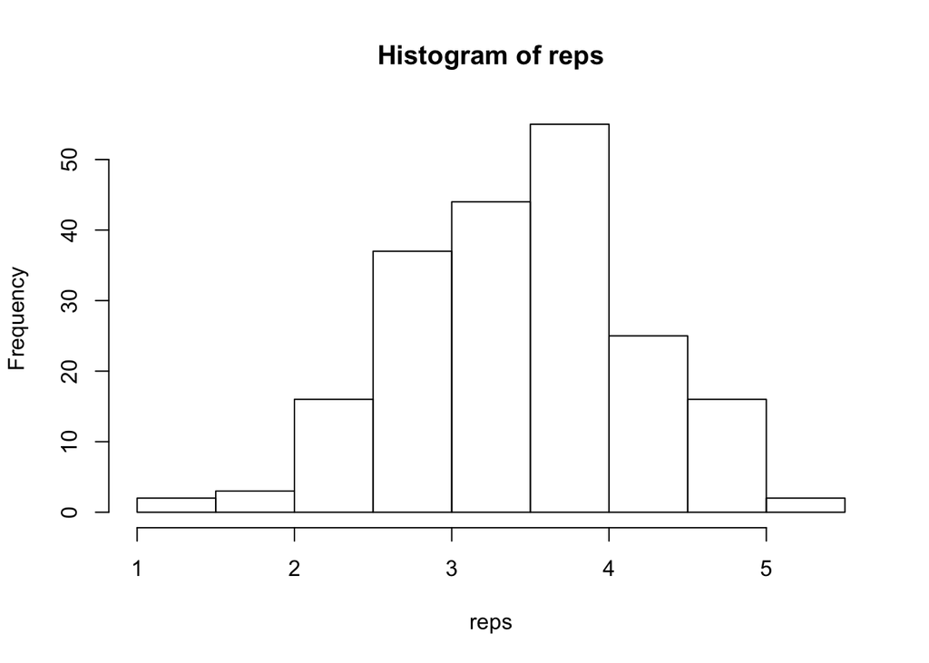

```r
hist(reps)
```

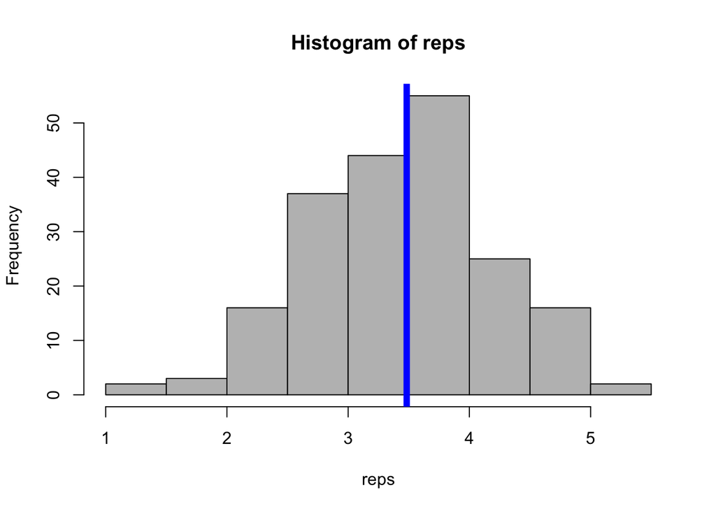

```r
hist(reps, col = "grey")
abline(v = mean(reps), col = "blue", lwd = 6)
```

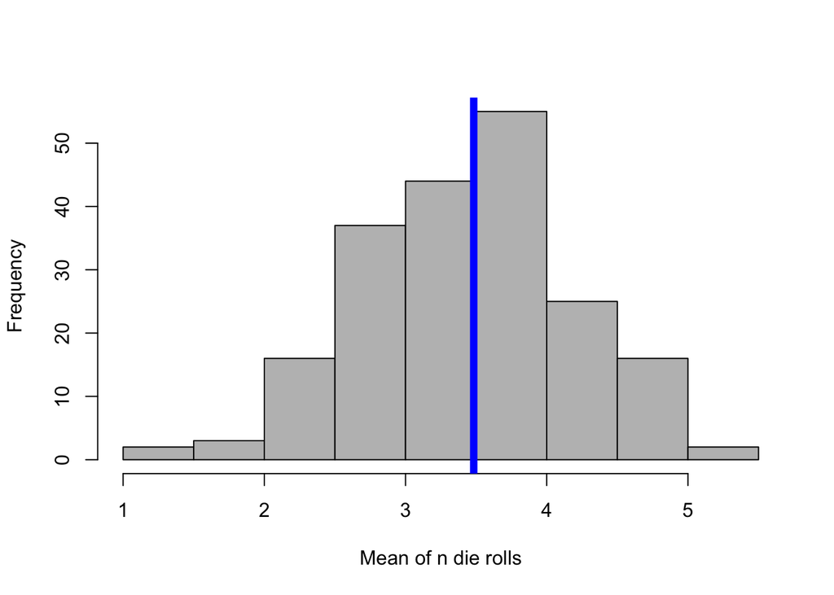

```r
my_hist <- function(sims){
    hist(sims, col = "grey", xlab = "Mean of n die rolls", main = "")
    abline(v = mean(sims), col = "blue", lwd = 6)
}

my_hist(sims = reps)
```

### 6.0.4 Monte Carlo simulation - Step 4 - automation

How would we update the function to add the number of die rolls as the title of the plot?

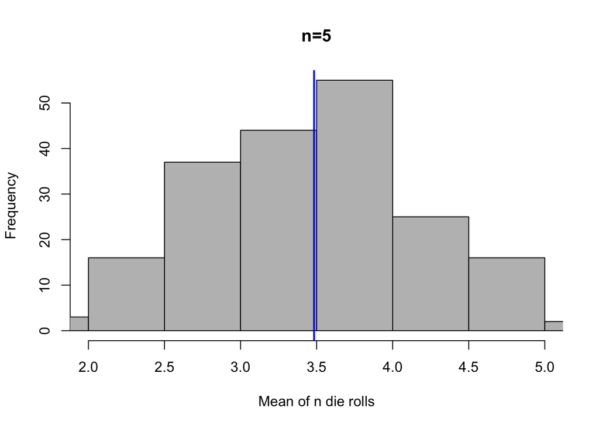

```r
my_hist <- function(sims, n){
    hist(sims, col = "grey",  xlab = "Mean of n die rolls",
         main = paste0("n=", n), xlim = c(2,5))
    abline(v = mean(sims), col = "blue", lwd = 2)
    }

my_hist(sims = reps, n = 5)
```

How can we use everything we learned today to analyze the changes in the the sampling distribution of the mean of the die rolls as the number of die rolls change?

We can integrate what we did above and write a loop that varies the number of die rolls over which we take the mean and plots the sampling distribution each time.

Say we want to see the sampling distribution for $n=10$, $n=25$, $n=50$, $n=100$, $n=200$, and $n=500$.

```r
nr_die_rolls <- c(10, 25, 50, 100, 200, 500)
```

Let’s see how we can first write this for $n=10$. Remember this is the first element of the vector, so we can get it using 1 as the index, `nr_die_rolls[1]`.

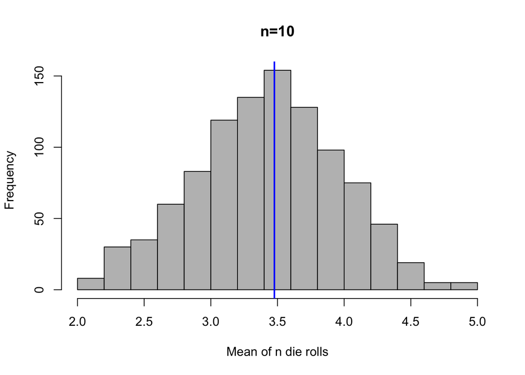

```r
reps <- replicate(1000, die_roll_mean(nr_rolls = nr_die_rolls[1]))
my_hist(sims = reps, n = nr_die_rolls[1])
```

We can now write a loop that works through the vector with the numnber of die rolls and produces the relevant plot for each iteration:

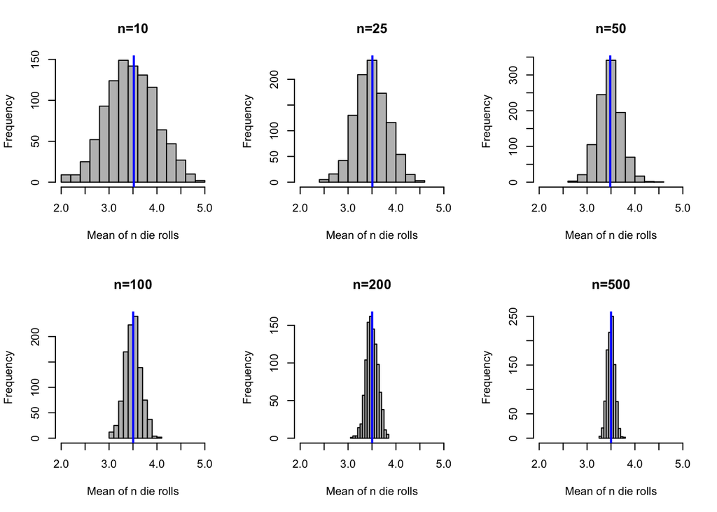

```r
par(mfrow = c(2,3))

for (i in 1:length(nr_die_rolls)) {
    reps <- replicate(1000, die_roll_mean(nr_rolls = nr_die_rolls[i]))
    my_hist(sims = reps, n = nr_die_rolls[i])
}
```

# 7 **Challenge 3:** The Birthday Problem

Say we choose 25 people at random. What is the probability two or more of them have the same birthday?’

Model simplifications: * Ignore leap years * Assume the probability of having a birthday in any of the 365 days of the year is equally likely (and no twins, triplets, etc. in the room).

Let’s start by thinking of one room. We need to sample 25 birthdays and check how many are repeated.

```r
set.seed(94705)
birthdays <- sample(1:365, 25, replace = TRUE)
birthdays
```

```
##  [1] 135 225 191 242 351 276  10 214 330 288 242 322 129 234  21  86  77
## [18]  17 103  46  23 289  85  54 174
```

We now want to know how many of those birthdays are repeated. For that we can use the `unique()` command.

```r
unique(birthdays)
```

```
##  [1] 135 225 191 242 351 276  10 214 330 288 322 129 234  21  86  77  17
## [18] 103  46  23 289  85  54 174
```

```r
length(unique(birthdays))
```

```
## [1] 24
```

24 birthdays are unique. Two people have the same birthday!

Note this is just one realization of the process. To use R to approximate the probability we would need to repeat this process many, many times.

For this we can start by writing a function that goes through the process one time and then use the `replicate` function as we did above.

We start by writing the function:

```r
set.seed(94705)
birthday_function <- function(people = 25){

    # we populate the room
    birthdays <- sample(1:365, people, replace = TRUE)

    # get the unique number of bdays
    unique_bdays <- length(unique(birthdays))

    # and return a 1 if at least one bday is repeated.
    as.numeric(unique_bdays != people)
}

birthday_function(people = 25)
```

```
## [1] 1
```

Thus, we have one repeat birthday!

Now we can use `replicate` to repeat the process 1,000 times:

```r
set.seed(94705)
many_sims <- replicate(1000, birthday_function(people = 25))
```

```r
many_sims
```

To approximate the probability of at least one matching birthday, we can just take the mean of this vector:

```r
mean(many_sims)
```

```
## [1] 0.578
```

Say we now want to use R to see how this probability changes as the number of people in the room changes. How can we do this? We can use our function but incorporating it into a loop which varies the number of people in the room:

```r
people <- 2:100
sims <- matrix(NA, nrow = length(people), ncol = 2)

for (i in 1:length(people)) {
    many_sims <- replicate(5000, birthday_function(people = people[i]))
    sims[i,] <- c(people[i], mean(many_sims))
}

head(sims)
```

```
##      [,1]   [,2]
## [1,]    2 0.0024
## [2,]    3 0.0076
## [3,]    4 0.0194
## [4,]    5 0.0328
## [5,]    6 0.0400
## [6,]    7 0.0570
```

```r
sims
```

Plot the probability:

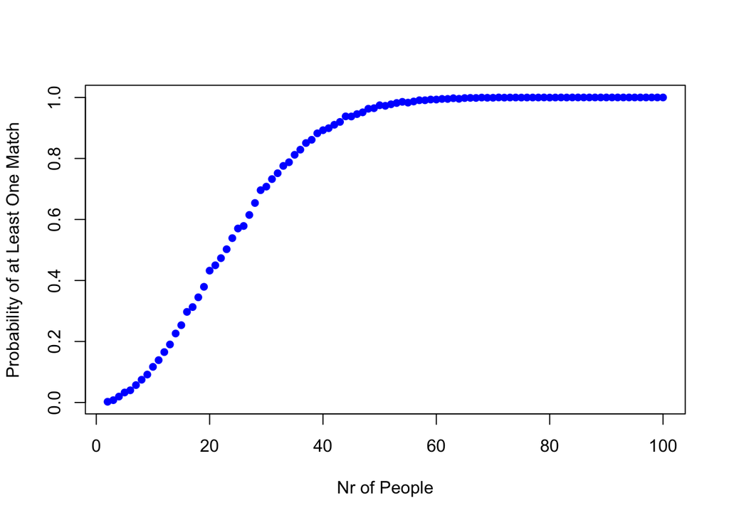

```r
par(mfrow = c(1,1))
plot(x = sims[,1], y = sims[,2],
     pch = 16, col = "blue",
     xlab = "Nr of People",
     ylab = "Probability of at Least One Match")
```

Learn more about the birthday problem [here](http://mathforum.org/dr.math/faq/faq.birthdayprob.html)

Although the “dplyr” R package is perhaps more useful for quickly applying functions to a matrix, there exists a whole family of functionals for this sort of thing in base R. Learn more about the “apply” functional family [here](https://www.r-bloggers.com/using-the-apply-family-of-functions-in-r/), [here](https://www.r-bloggers.com/using-apply-sapply-lapply-in-r/), and [here](http://adv-r.had.co.nz/Functionals.html).

Also see [this helpful walkthrough](http://adv-r.had.co.nz/Functions.html)

# 8 Acknowledgements

[Software Carpentry](https://swcarpentry.github.io/)  
[Hadley Wickham](http://adv-r.had.co.nz/)  
[more Hadley Wickham](http://r-pkgs.had.co.nz/)  
- Contributions by Guadalupe Tuñón, Evan Muzzall, Dillon Niederhut, Shinhye Choi, Rochelle Terman.